# CURSO CIENCIA DE DATOS - CLASE 9

Angie Scetta

UTDT, 2022

# ANÁLISIS Y GEOPROCESAMIENTO DE DATOS

En la clase anterior hicimos una introducción a los datos espaciales y vimos los siguientes temas:

- Abrir y analizar datos espaciales: El paquete *sf*.
- Unir datos espaciales y datos “tradicionales”: La función *left_join()*.

Pero todavía nos queda mucho camino por recorrer en el mundo de los datos espaciales así que a continuación abordaremos algunos temas más.

Por ejemplo, reiteradas veces nos vamos a encontrar con que queremos unir 2 dataset que no tienen columnas en común pero hay algo que si comparten: su ubicación en el espacio.

Podemos unir datos a partir de sus ubicaciones espaciales realizando un “Spatial Join” o “Unión Espacial” y en R lo haremos a partir de la función *st_join()* que forma parte del ya conocido paquete *sf*. Cualquier duda pueden revisar la [documentación de la librería](https://cran.r-project.org/web/packages/sf/sf.pdf).

Pero vamos por partes ya que aún nos quedan aprender algunos pasos previos a la unión espacial. Continuemos trabajando con el [dataset de partidos_amba](https://data.world/angie-scetta/partidos-amba-geo) y carguemos una nueva base de datos: un dataset tradicional que tenga como conexión al territorio las coordenadas geográficas x e y (longitud y latitud).

## Unir datos por sus ubicaciones espaciales

A continuación trabajaremos con los datos propiedades en venta de Properati, un portal web de compra, venta y alquiler de inmuebles en toda América Latina. Estos datos son públicos y pueden encontrarlos en el siguiente [link](https://www.properati.com.ar/data).

Pero en este caso, para facilitar la manipulación de la información durante la clase, usaremos un set de datos (en formato .csv) previamente procesado que contiene datos de propiedades en venta publicadas en AMBA en Junio de 2021. [Pueden descargarlo desde este link](https://data.world/angie-scetta/properati-junio2021)

*Recomendación: Al descargarlo del campus, moverlo de la carpeta “Descargas” a la carpeta llamada “data” dentro de la carpeta del Proyecto donde estén trabajando.*

Ahora si, ¡Manos a la obra! Activemos nuestras 2 librerías:

```r
#install.packages(tidyverse)
library(tidyverse)
#install.packages(sf)
library(sf)
```

Y carguemos nuestros 2 datsets:

```r
partidos_amba <- st_read("data/partidos_amba.geojson", stringsAsFactors = TRUE)
properati <- read.csv("data/amba_properati2021.csv", stringsAsFactors = TRUE)
```

Veamos que información contiene nuestro dataset de Properati:

```r
names(properati)
```

```
##  [1] "created_on"      "rooms"           "surface_total"   "surface_covered"
##  [5] "price"           "currency"        "property_type"   "operation_type"
##  [9] "lat"             "lon"
```

Las columnas tienen fecha de publicación de la propiedad, cantidad de ambientes, superficie total y superficie cubierta, precio publicado, tipo de moneda (ARS o USD), tipo de propiedad, tipo de operación, y finalmente la ubicación del inmueble con sus coordenadas: latitud y longitud.

Veamos un resumen de nuestros datos:

```r
summary(properati)
```

```
##    created_on         rooms        surface_total    surface_covered
##  Min.   :202106   Min.   : 1.000   Min.   :  17.0   Min.   : 16.0
##  1st Qu.:202106   1st Qu.: 2.000   1st Qu.:  55.0   1st Qu.: 49.0
##  Median :202106   Median : 3.000   Median :  84.0   Median : 71.0
##  Mean   :202106   Mean   : 3.332   Mean   : 129.2   Mean   :101.7
##  3rd Qu.:202106   3rd Qu.: 4.000   3rd Qu.: 154.0   3rd Qu.:122.0
##  Max.   :202106   Max.   :10.000   Max.   :4400.0   Max.   :800.0
##      price         currency        property_type  operation_type
##  Min.   :  15000   USD:6111   Casa        :1675   Venta:6111
##  1st Qu.:  94000              Departamento:3743
##  Median : 145000              PH          : 693
##  Mean   : 210965
##  3rd Qu.: 240000
##  Max.   :2900000
##       lat              lon
##  Min.   :-35.12   Min.   :-59.02
##  1st Qu.:-34.64   1st Qu.:-58.54
##  Median :-34.60   Median :-58.46
##  Mean   :-34.61   Mean   :-58.47
##  3rd Qu.:-34.56   3rd Qu.:-58.41
##  Max.   :-34.15   Max.   :-57.85
```

Ya podemos ir generando algunos insights:

- Los registros corresponden al mes de Junio 2021.
- La propiedad de menor superficie cubierta tiene 16 m2 y la de mayor tiene 800 m2.
- La mayoría de las propiedades publicadas son departamentos (3.743).

Como habrán notado, no hay ninguna variable que tenga la misma información que el dataset espacial y por lo tanto no vamos a poder unirlos tan fácilmente con *left_join()* como hicimos la clase pasada. Acá vamos a tener que utilizar si o si la ubicación espacial de ambos datasets.

Comencemos utilizando la longitud y latitud en un gráfico de puntos para ver como lucen en el espacio:

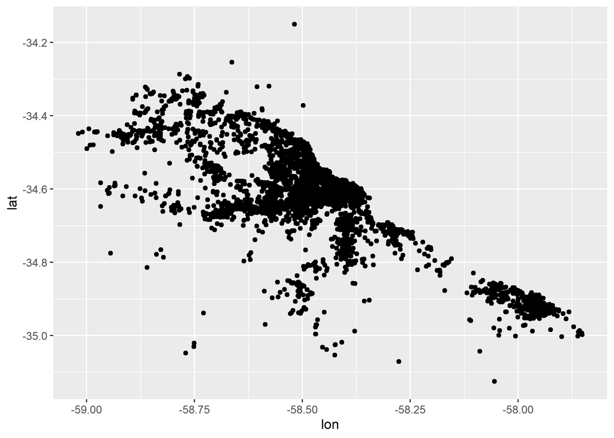

```r
ggplot(properati) +
  geom_point(aes(x=lon, y=lat))
```

Con mucha imaginación uno puede darse cuenta que los datos tienen la forma de AMBA, pero está faltando información que nos facilite la lectura del mismo. Para esto agreguemos nuestro dataset espacial de fondo así contextualizamos un poco la información, pero siempre teniendo en cuenta 2 cosas:

- Cuando utilizamos 2 capas (en este caso geom_sf() y geom_point()), tenemos que asignarle a cada una el dataset correspondiente dentro de la capa y ggplot() queda “vacío”.
- Las capas se grafican en el mismo orden que se escribe el código, es decir que la que agregamos primero (en este caso partidos_amba) será el fondo de la que agreguemos luego (properati).

Veamos esto en detalle:

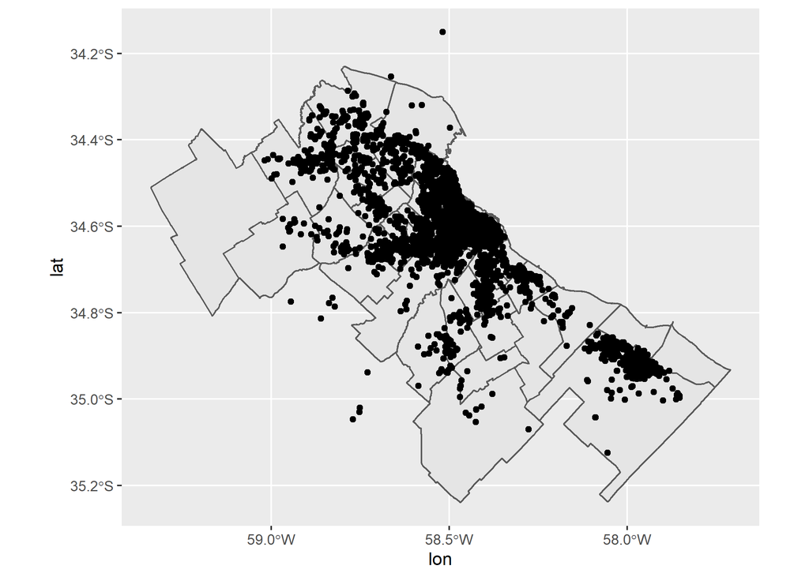

```r
ggplot()+
  geom_sf(data=partidos_amba)+
  geom_point(data=properati, aes(x=lon, y=lat))
```

Ahora si! Mucho más clara la ubicación de las propiedades publicadas.

Parece que tienen algo en común el dataset de partidos y el de Properati, ¿No? Se solapan en el espacio y eso es justo lo que necesitábamos para poder realizar nuestra unión espacial!

Pero antes de seguir, vale aclarar que el segundo dataset que cargamos sigue siendo “tradicional” y para poder hacer una unión espacial, ambos deben ser espaciales. Por lo tanto, tenemos que transformarlo a este formato, y por suerte el paquete *sf* tiene una función muy sencilla de utilizar que se llama *st_as_sf()*:

```r
properati_geo <- properati %>%
    st_as_sf(coords = c("lon", "lat"), crs = 4326)
```

Revisemos que efectivamente haya ocurrido lo que queríamos:

```r
class(properati_geo)
```

```
## [1] "sf"         "data.frame"
```

Perfecto, properati_geo es un dataset espacial u objeto del tipo “sf”, que hace referencia a “simple features” por estar compuesto de geometrías bidimensionales (en este caso puntos).

Veamos si se agregó el campo geometry:

```r
head(properati_geo)
```

```
## Simple feature collection with 6 features and 8 fields
## Geometry type: POINT
## Dimension:     XY
## Bounding box:  xmin: -58.90955 ymin: -34.61551 xmax: -58.38517 ymax: -34.45655
## Geodetic CRS:  WGS 84
##   created_on rooms surface_total surface_covered  price currency property_type
## 1     202106     1            26              20  62000      USD            PH
## 2     202106     1            60              40  90000      USD          Casa
## 3     202106     1            48              36  75000      USD  Departamento
## 4     202106     1            40              36  99500      USD  Departamento
## 5     202106     1            28              28  68000      USD  Departamento
## 6     202106     1            91              53 135000      USD  Departamento
##   operation_type                    geometry
## 1          Venta POINT (-58.38517 -34.61551)
## 2          Venta  POINT (-58.65276 -34.4987)
## 3          Venta POINT (-58.90955 -34.45655)
## 4          Venta POINT (-58.47684 -34.56799)
## 5          Venta  POINT (-58.4227 -34.58355)
## 6          Venta POINT (-58.42886 -34.59237)
```

Tal como esperábamos, nuestro dataset de Properati se transformó en espacial y eso lo vemos con el reemplazo de sus columnas X e Y por una única columna llamada “geometry”. Hagamos un mapa y veamos que pasa:

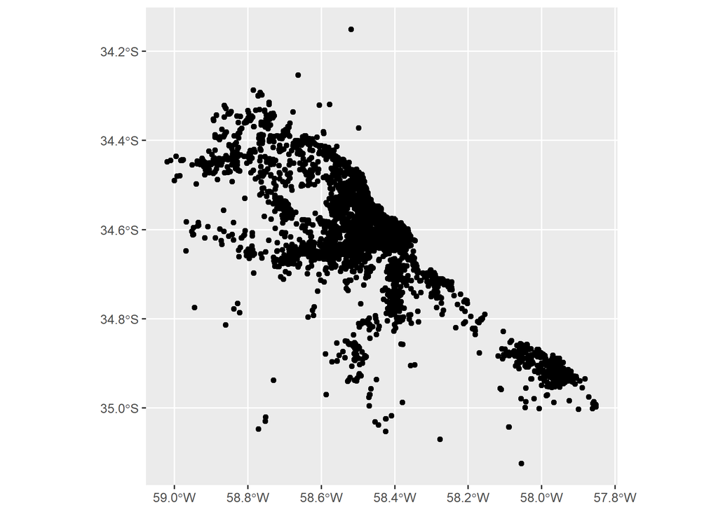

```r
ggplot(properati_geo)+
  geom_sf()
```

Y probemos agregando un poco de color y dejando los partidos por debajo:

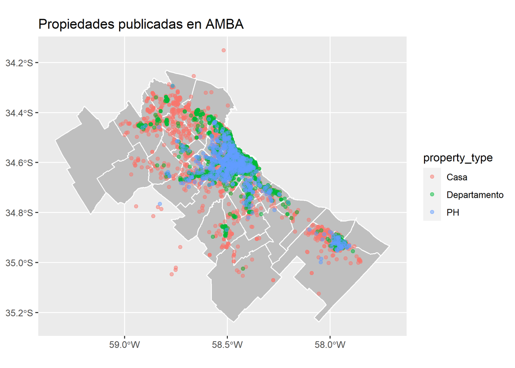

```r
ggplot()+
  geom_sf(data=partidos_amba, fill="gray75", color="white")+
  geom_sf(data=properati_geo, aes(color=property_type), alpha=0.5)+
  labs(title="Propiedades publicadas en AMBA")
```

A simple vista los datos son iguales que cuando hicimos el *geom_point()* pero la diferencia es que ahora son espaciales y por lo tanto… ¡Ya estamos en condiciones de unirlos con otro dataset espacial!

Llegó momento, hagamos nuestra unión espacial con *st_join()* para que, cada registro de properati_geo sume una nueva columna que indique a que partido pertenece:

```r
properati_geo <- st_join(properati_geo, partidos_amba)
```

Cabe destacar que, en el *st_join()*, al igual que en el *left_join()*, del lado izquierdo se pone el dataset al que queremos unirle información nueva y del lado derecho el dataset del que queremos extraer la información.

Revisemos el resultado!

```r
summary(properati_geo)
```

```
##    created_on         rooms        surface_total    surface_covered
##  Min.   :202106   Min.   : 1.000   Min.   :  17.0   Min.   : 16.0
##  1st Qu.:202106   1st Qu.: 2.000   1st Qu.:  55.0   1st Qu.: 49.0
##  Median :202106   Median : 3.000   Median :  84.0   Median : 71.0
##  Mean   :202106   Mean   : 3.332   Mean   : 129.2   Mean   :101.7
##  3rd Qu.:202106   3rd Qu.: 4.000   3rd Qu.: 154.0   3rd Qu.:122.0
##  Max.   :202106   Max.   :10.000   Max.   :4400.0   Max.   :800.0
##
##      price         currency        property_type  operation_type
##  Min.   :  15000   USD:6111   Casa        :1675   Venta:6111
##  1st Qu.:  94000              Departamento:3743
##  Median : 145000              PH          : 693
##  Mean   : 210965
##  3rd Qu.: 240000
##  Max.   :2900000
##
##        nombre     provincia      area_km2               geometry
##  Comuna 14: 503   CABA:3134   Min.   :  6.30   POINT        :6111
##  La Plata : 447   GBA :2966   1st Qu.: 14.73   epsg:4326    :   0
##  Comuna 13: 418   NA's:  11   Median : 22.14   +proj=long...:   0
##  Comuna 12: 318               Mean   :141.85
##  Tigre    : 290               3rd Qu.:120.68
##  (Other)  :4124               Max.   :889.49
##  NA's     :  11               NA's   :11
```

A cada registro se le unió una columna del nombre del partido con el que se solapa. Pero acá aparece algo nuevo, algunos valores nulos o NA´s que hacen referencia a aquellas propiedades ubicadas fuera de los partidos de AMBA (es decir que no solaparon). Veamos esto en un mapa así queda más claro:

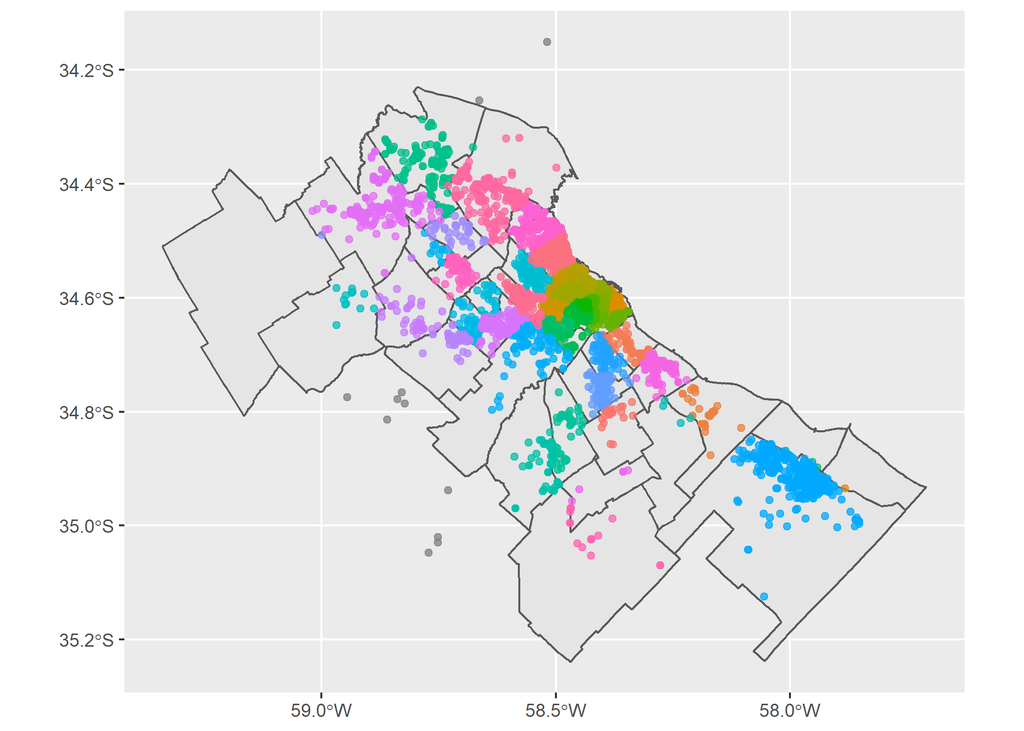

```r
ggplot()+
  geom_sf(data=partidos_amba)+
  geom_sf(data=properati_geo, aes(color=nombre), alpha=0.75, show.legend = FALSE)
```

Se ve como todos los puntos que se ubican en AMBA tienen color según sus partidos, pero los puntos fuera de AMBA quedaron grises porque su valor es *NA*.

Para “limpiar” esto filtremos todos los registros que tienen partido asignado:

```r
properati_geo <- properati_geo %>%
  filter(!is.na(nombre))
```

Visualicemos nuevamente:

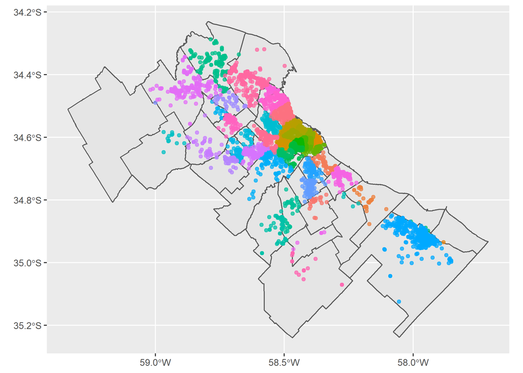

```r
ggplot()+
  geom_sf(data=partidos_amba)+
  geom_sf(data=properati_geo, aes(color=nombre), alpha=0.75, show.legend = FALSE)
```

Ya tenemos solo los registros de AMBA. ¿Pero ahora cómo hacemos si queremos realizar un mapa coroplético como los de la clase anterior pero coloreando los partidos según la cantidad de propiedades publicadas que tienen o según el valor del m2 promedio? Nuevamente manipulamos el set de datos con group_by() y luego utilizamos left_join():

```r
properati_geo <- properati_geo %>%
  group_by(nombre) %>%
  summarise(cantidad=n(),
            valor_m2=mean(price/surface_covered))
```

```r
head(properati_geo)
```

```
## Simple feature collection with 6 features and 3 fields
## Geometry type: GEOMETRY
## Dimension:     XY
## Bounding box:  xmin: -58.52936 ymin: -34.93481 xmax: -57.8822 ymax: -34.58482
## Geodetic CRS:  WGS 84
## # A tibble: 6 × 4
##   nombre          cantidad valor_m2                                     geometry
##   <fct>              <int>    <dbl>                               <GEOMETRY [°]>
## 1 Almirante Brown       22    1341. MULTIPOINT ((-58.35463 -34.81037), (-58.335…
## 2 Avellaneda            73    1310. MULTIPOINT ((-58.30226 -34.69496), (-58.301…
## 3 Berazategui           30    1546. MULTIPOINT ((-58.10421 -34.82882), (-58.170…
## 4 Berisso                1    1200                    POINT (-57.8822 -34.93481)
## 5 Comuna 1             267    3122. MULTIPOINT ((-58.37084 -34.62929), (-58.370…
## 6 Comuna 10             95    1990. MULTIPOINT ((-58.52936 -34.61466), (-58.526…
```

```r
properati_geo <- properati_geo %>%
  st_set_geometry(NULL)
```

```r
head(properati_geo)
```

```
## # A tibble: 6 × 3
##   nombre          cantidad valor_m2
##   <fct>              <int>    <dbl>
## 1 Almirante Brown       22    1341.
## 2 Avellaneda            73    1310.
## 3 Berazategui           30    1546.
## 4 Berisso                1    1200
## 5 Comuna 1             267    3122.
## 6 Comuna 10             95    1990.
```

Ahora si, solo tiene 3 columnas con el nombre del partido, la cantidad de propiedades y el valor promedio del m2, pero ya no tiene geometría. Procedamos a realizar la unión:

```r
partidos_amba <- left_join(partidos_amba, properati_geo, by="nombre")
```

Probemos mapear las cantidades:

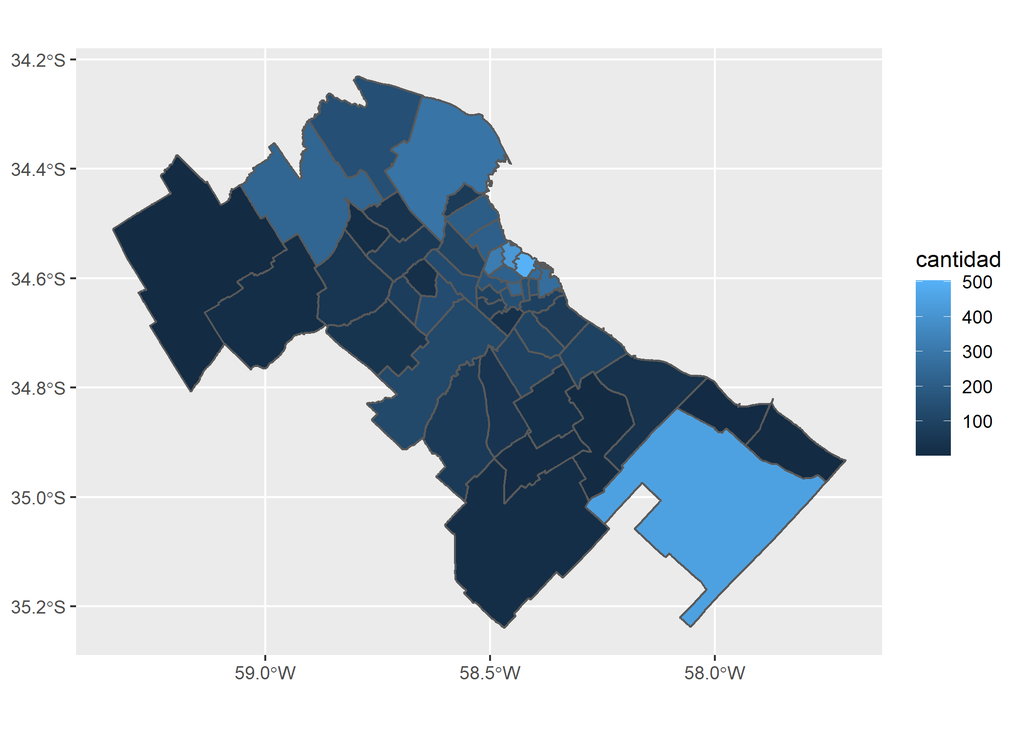

```r
ggplot()+
  geom_sf(data=partidos_amba, aes(fill=cantidad))
```

Ya tenemos un mapa de cantidad de propiedades en venta por partido, y podemos ver como la mayor cantidad de concentra en la Comuna 14 (CABA), seguida por La Plata (GBA).

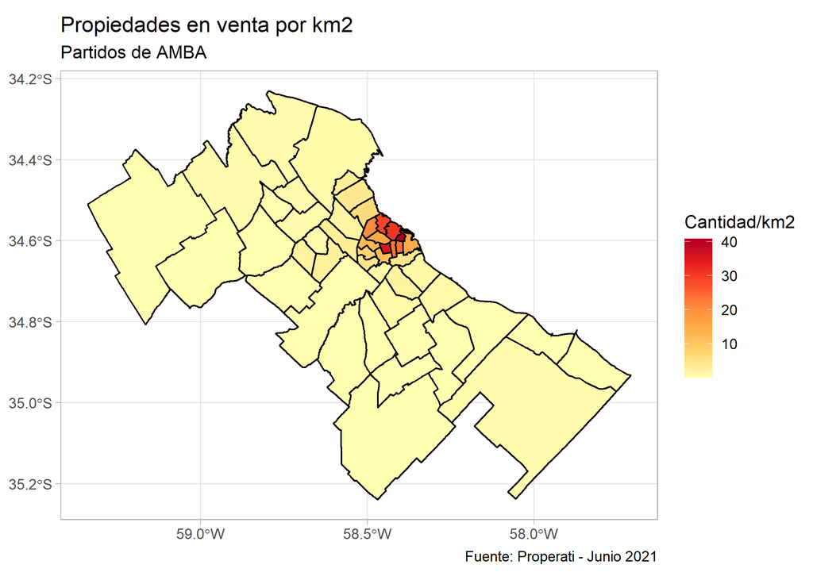

```r
ggplot()+
  geom_sf(data=partidos_amba, aes(fill=cantidad/area_km2), color="black")+
    labs(title = "Propiedades en venta por km2",
         subtitle = "Partidos de AMBA",
         fill = "Cantidad/km2",
         caption= "Fuente: Properati - Junio 2021") +
  scale_fill_distiller(palette = "YlOrRd", direction = 1) +
  theme_light()
```

Y ahora veamos un mapa coroplético de valor de venta del m2:

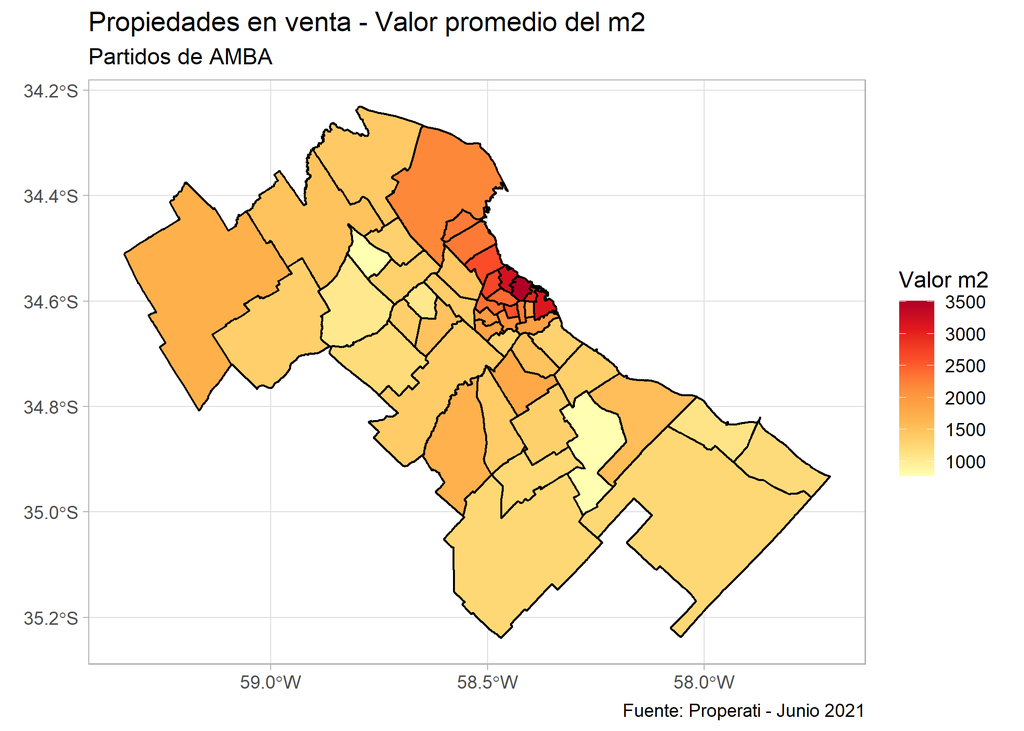

```r
ggplot()+
  geom_sf(data=partidos_amba, aes(fill=valor_m2), color="black")+
    labs(title = "Propiedades en venta - Valor promedio del m2",
         subtitle = "Partidos de AMBA",
         fill = "Valor m2",
         caption= "Fuente: Properati - Junio 2021") +
  scale_fill_distiller(palette = "YlOrRd", direction = 1) +
  theme_light()
```

## Agregar geometrías extra

Muchas veces nos vamos a encontrar con que queremos sumar más capas para darle mayor contexto a nuestro mapa. ¿Cómo lo hacemos? Fácil! agregando más *geom_sf()* al *ggplot*. Veamos un ejemplo y carguemos el [geoJSON de las líneas de FFCC](https://data.world/angie-scetta/lineas-ffcc):

```r
lineas_ffcc <- st_read("data/lineas_ffcc.geojson")
```

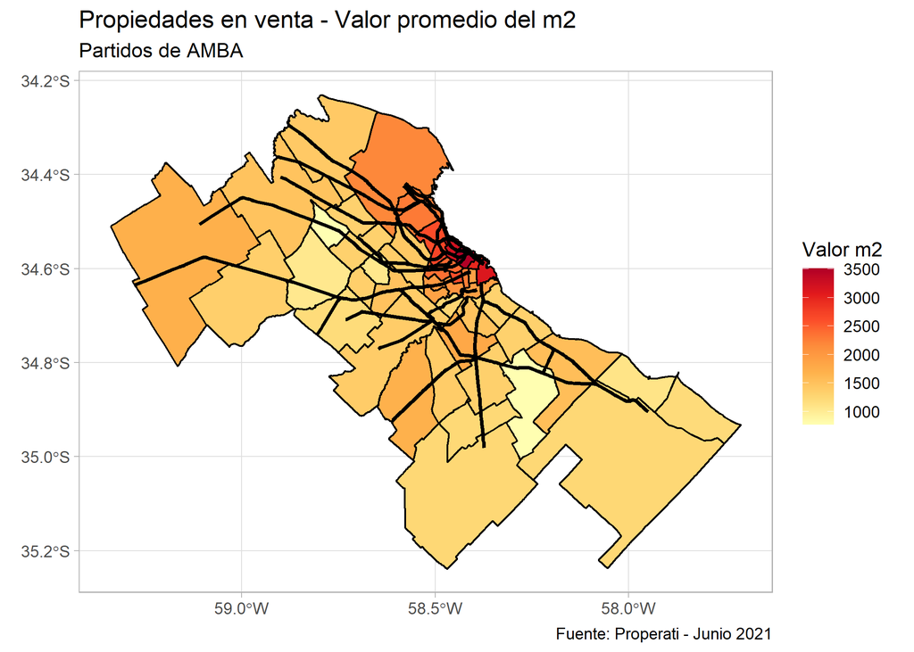

```r
ggplot()+
  geom_sf(data=partidos_amba, aes(fill=valor_m2), color="black")+
    labs(title = "Propiedades en venta - Valor promedio del m2",
         subtitle = "Partidos de AMBA",
         fill = "Valor m2",
         caption= "Fuente: Properati - Junio 2021") +
  scale_fill_distiller(palette = "YlOrRd", direction = 1) +
  geom_sf(data=lineas_ffcc, size=1)+
  theme_light()
```

Ahora mejoremos un poco la estética y resaltemos las líneas de FFCC:

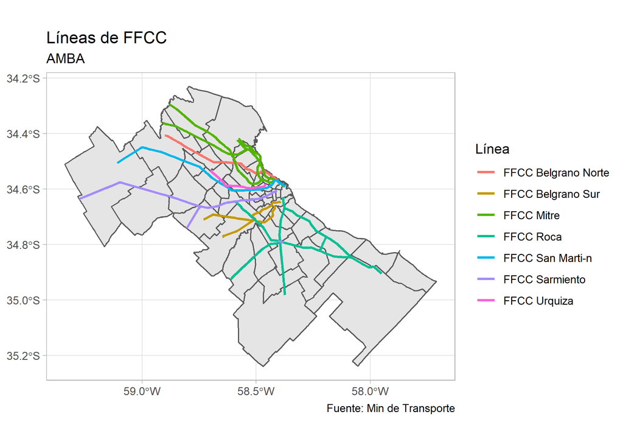

```r
ggplot()+
  geom_sf(data=partidos_amba) +
  geom_sf(data=lineas_ffcc, aes(color=as.factor(LINEA)), size=1) +
    labs(title = "Líneas de FFCC",
         subtitle = "AMBA",
         color = "Línea",
         caption= "Fuente: Min de Transporte") +
  theme_light()
```

## Agregar mapa base

Si bien hasta aquí hemos hecho mapas bastante completos, nunca está de más agregar un fondo que nos ayude a interpretar mejor el contexto de los datos que estamos analizando.

Para lograr esto utilizaremos la librería *ggmap* que nos permitirá añadir una capa que funcione como base de nuestros mapas. Cabe destacar que, este paquete utiliza recursos de diferentes APIs (Google, Stamenmap, etc), y por lo tanto es necesario tener conexión a internet al momento de utilizarlo. Cualquier duda pueden consultar la [documentación de ggmap](https://cran.r-project.org/web/packages/ggmap/ggmap.pdf).

Pero antes de seguir debemos instalarla y activarla:

```r
#install.packages(ggmap)
library(ggmap)
```

Una vez activada nuestra librería, el siguiente paso es determinar cuál es la “bounding box” o caja de coordenadas de mi dataset espacial. Es decir, cuáles son los límites geográficos del cuadro que contiene todos los datos.

Para esto, utilizaremos la función *st_bbox()* sobre el dataset espacial que tiene mayor cobertura en el especio: los partidos del AMBA.

```r
bbox_amba <- st_bbox(partidos_amba)
```

```r
bbox_amba
```

```
##      xmin      ymin      xmax      ymax
## -59.33920 -35.23893 -57.70946 -34.23007
```

Bien, ya tengo los 4 valores que delimitan mi *bounding box*, pero el formato es de tipo “bbox” y para utilizar *ggmap* necesitamos que sea de tipo numérico, así que modifiquemoslo:

```r
bbox_amba <- as.numeric(bbox_amba)
```

Ahora vamos a usar *get_stamenmap()* para descargar de internet el “mapa base”. En este caso utilizaremos un mapa de tipo “toner-lite” pero hay otras opciones que pueden verse [en este link](http://maps.stamen.com/)

```r
mapa_amba <- get_stamenmap(bbox = bbox_amba,
                     maptype = "toner-lite",
                     zoom=10)
```

Con *ggmap()* veamos que nos hemos descargado:

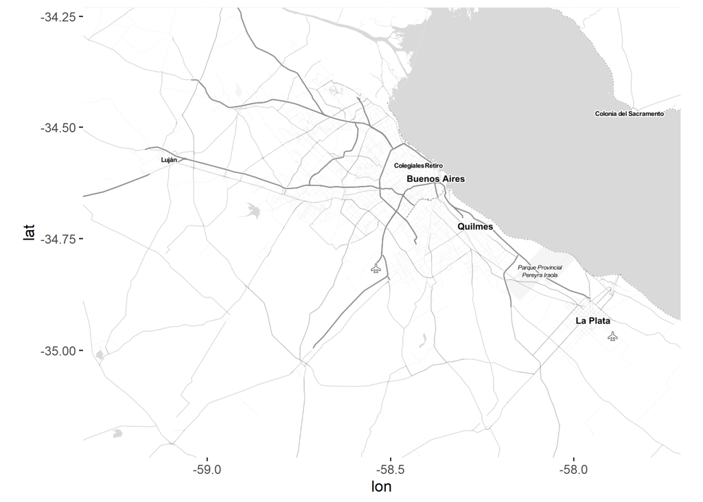

```r
ggmap(mapa_amba)
```

Ahora podemos reutilizar el código de alguno de los mapas anteriores, simplemente reemplazando la primera línea, donde iniciamos un objeto ggplot por una línea que llame a nuestro mapa base con *ggmap()* y luego agregando el parámetro “inherit.aes=FALSE” dentro del *geom_sf()* para anular la estética predeterminada del objeto:

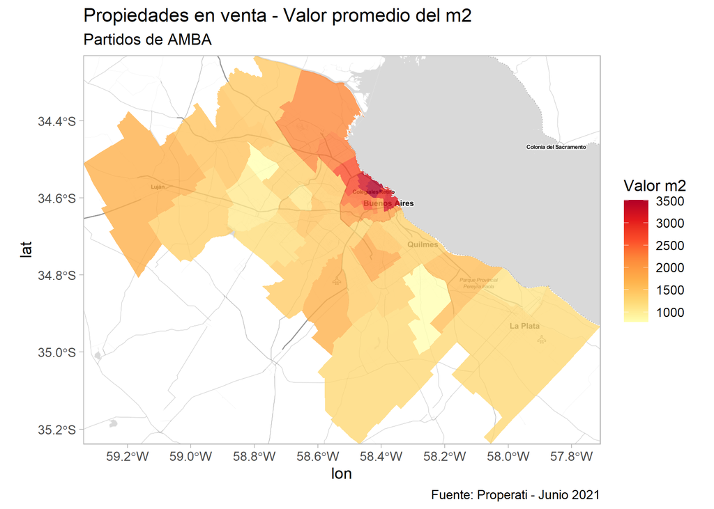

```r
ggmap(mapa_amba)+
  geom_sf(data=partidos_amba, aes(fill=valor_m2), color=NA, inherit.aes=FALSE, alpha=0.8)+
    labs(title = "Propiedades en venta - Valor promedio del m2",
         subtitle = "Partidos de AMBA",
         fill = "Valor m2",
         caption= "Fuente: Properati - Junio 2021") +
  scale_fill_distiller(palette = "YlOrRd", direction = 1) +
  theme_light()
```

Listo! Ya tenemos un mapa con fondo y con información que generamos nosotros a partir de un cruce de 2 bases de datos.

## Ejercicios de práctica

1. Elegir una ciudad de cualquier parte del mundo que les interese y que disponga de un portal de datos abiertos que ofrezca un dataset espacial (formato geojson o shp) de polígonos con alguna división geográfica: barrios, comunas, etc.
2. Del mismo portal de datos donde descargaron el dataset espacial, o de otra fuente si la tienen, elegir un dataset con registros geo-referenciados. Por ejemplo, las escuelas de la ciudad (o las comisarías, o las propiedades en alquiler, etc) con sus coordenadas. Puede ser en formato csv o shapefile.
3. Realizar un “join espacial”, asignando a cada registro geo-referenciado la unidad geográfica (barrio, comuna, etc) que le corresponda y utilizar ggplot() para realizar un mapa coroplético con los límites de los barrios, cuyo color de relleno indique la cantidad encontrada en cada uno.
4. Agregar un mapa base a elección para dar contexto al mapa realizado en el punto 3.